# Heart Failure Prediction

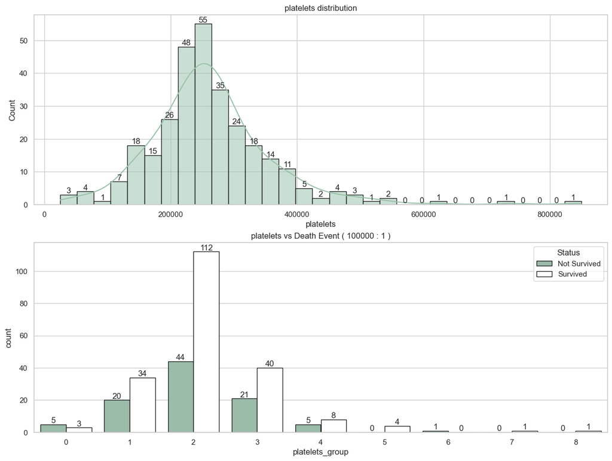

```python
numplot(df,'platelets',10**5)
```

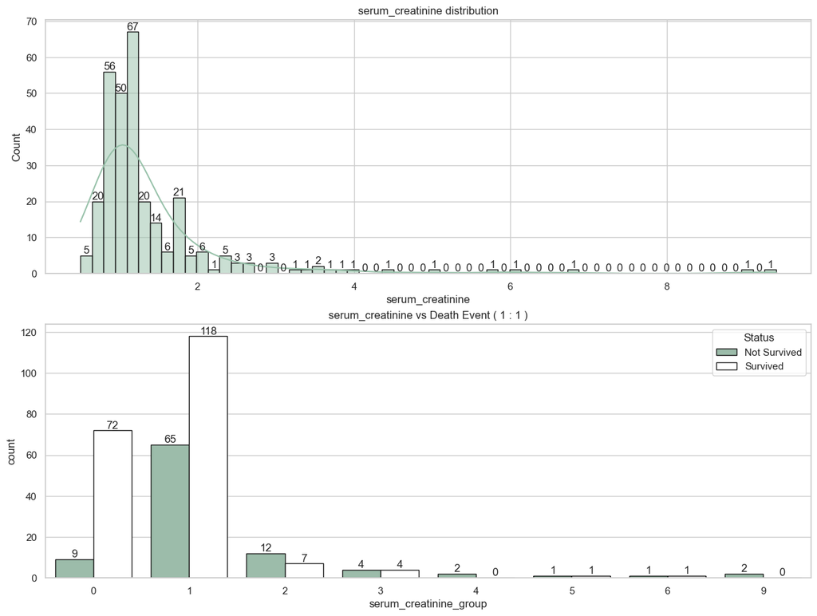

```python
numplot(df,'serum_creatinine',1)
```

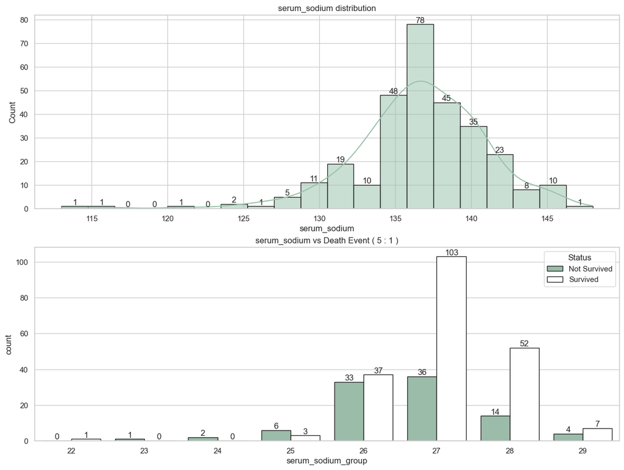

```python
numplot(df,'serum_sodium',5)
```

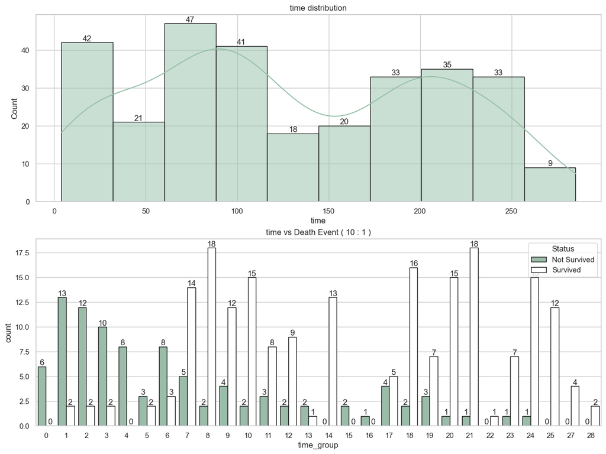

```python
numplot(df,'time',10)
```

## Sumary

### Numerical Features Insight

• Cases of DEATH_EVENT initiate from the age of 45. Some specific peaks of high cases of • DEATH_EVENT can be observed at 45, 50, 60, 65, and 70 • High cases of DEATH_EVENT can be observed for ejaction_fraction values from 20 - 60. • serum_creatinine values from 0.6 to 3.0 have higher probability to lead to DEATH_EVENT. • serum_sodium values 127 - 145 indicate towards a DEATH_EVENT due to heart failure. • DEATH_EVENT cases are on a high for the values between 0(0x100) - 500(5x100) for • creatinine_phosphokinase. • platelets values between 0(0x10^5) - 400,000(4x10^5) are prone to heart failures leading to • DEATH_EVENT. • For the time feature, values from 0(0x10) - 60(6*10) have higher probability to lead to a DEATH_EVENT

### Categorical Features Sumary :

age : 50 - 70 creatinine_phosphokinase : 0 - 500 ejaction_fraction : 20 - 40 platelets : 200,000 - 300,000 serum_creatinine : 1 - 2 serum_sodium : 130 - 140

### General Information

age : General aging leads to heart failures. creatinine_phosphokinase : > 120 mcg/L ejection_fraction : Normal Range 55% - 70%. Below 55% is prone to heart failures. platelets : Low and very high values of platelets led to heart failure. serum_creatinine : 0.8 - 1.7 (mg/dL) is the range of values that leads to most heart failures. serum_sodium : Above 130 (mEq/L), chances of heart failure increases by alot. time : Ideal follow-up period is of 14 days. Anything above 14 days can lead to worse situations.

# Features Engineering

### Scaling

```python
mms = MinMaxScaler() # Normalization
ss = StandardScaler() # Standardization
# Normalization
df['age'] = mms.fit_transform(df[['age']])
df['creatinine_phosphokinase'] = mms.fit_transform(df[['creatinine_phosphokinase']])
df['ejection_fraction'] = mms.fit_transform(df[['ejection_fraction']])
df['serum_creatinine'] = mms.fit_transform(df[['serum_creatinine']])
df['time'] = mms.fit_transform(df[['time']])
# Standardization
df['platelets'] = ss.fit_transform(df[['platelets']])
df['serum_sodium'] = ss.fit_transform(df[['serum_sodium']])
df.head()
```

|  | age | anaemia | creatinine_phosphokinase | diabetes | ejection_fraction | high_blood_pressure | platelets | serum_creatinine | serum_sodium | sex | ... | time | DEATH_EVENT | Status | age_group | creatinine_phosphokinase_group | ejection_fraction_group | platelets_group | serum_creatinine_group | serum_sodium_group | time_group |
| --- | --- | --- | --- | --- | --- | --- | --- | --- | --- | --- | --- | --- | --- | --- | --- | --- | --- | --- | --- | --- | --- |
| 0 | 0.636364 | 0 | 0.071319 | 0 | 0.090909 | 1 | 1.681651e-02 | 0.157303 | -1.504036 | 1 | ... | 0.000000 | 1 | Not Survived | 15 | 5 | 2 | 2 | 1 | 26 | 0 |
| 1 | 0.272727 | 0 | 1.000000 | 0 | 0.363636 | 0 | -2.740240e-07 | 0.067416 | -0.141976 | 1 | ... | 0.007117 | 1 | Not Survived | 11 | 78 | 3 | 2 | 1 | 27 | 0 |
| 2 | 0.454545 | 0 | 0.015693 | 0 | 0.090909 | 0 | -1.038073e+00 | 0.089888 | -1.731046 | 1 | ... | 0.010676 | 1 | Not Survived | 13 | 1 | 2 | 1 | 1 | 25 | 0 |
| 3 | 0.181818 | 1 | 0.011227 | 0 | 0.090909 | 0 | -5.464741e-01 | 0.157303 | 0.085034 | 1 | ... | 0.010676 | 1 | Not Survived | 10 | 1 | 2 | 2 | 1 | 27 | 0 |
| 4 | 0.454545 | 1 | 0.017479 | 1 | 0.090909 | 0 | 6.517986e-01 | 0.247191 | -4.682176 | 0 | ... | 0.014235 | 1 | Not Survived | 13 | 1 | 2 | 3 | 2 | 23 | 0 |

5 rows × 21 columns

### Correlation

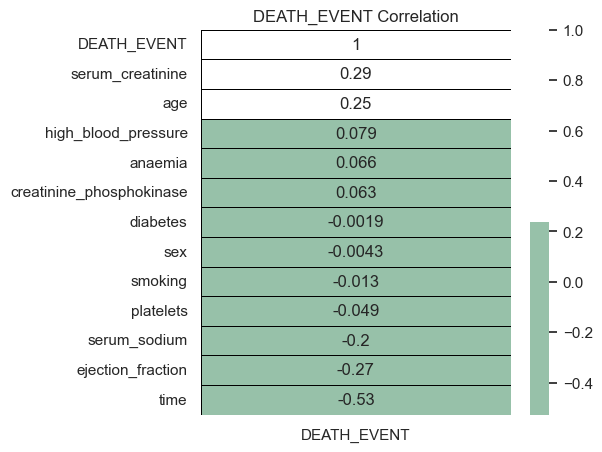

```python
corr = data.corrwith(data['DEATH_EVENT']).sort_values(ascending = False).to_frame()
corr.columns = ['DEATH_EVENT']
plt.subplots(figsize = (5,5))
sns.heatmap(corr,annot = True,cmap = colors,linewidths = 0.4,linecolor = 'black');
plt.title('DEATH_EVENT Correlation');
```

### Insight :

Features like high_blood_pressure, anaemia, creatinine_phosphokinase, diabetes, sex, smoking, and platelets do not display any kind of correlation with DEATH_EVENT

##### We will create 2 models :

```python
df1=data.copy()
df2=data.copy()
# Dataset for model based on Statistical Test :
df1 = df1.drop(columns = ['anaemia', 'diabetes', 'high_blood_pressure','creatinine_phosphokinase', 'sex', 'smoking','platelets'])
# Dataset for model based on General Information :
df2 = df2.drop(columns = ['sex','platelets'])
```